# Keras 다중 선형회귀

tester

2022 2 9

이번 포트폴리오에서는 Keras패키지를 사용하여 다중선형회귀를 하고, R 내장 회귀함수와 결과를 비교하고자 한다.

# 보스턴 주택 가격 데이터셋

```r
train_df
```

```
## # A tibble: 404 x 14
##      CRIM    ZN INDUS  CHAS   NOX    RM   AGE   DIS   RAD   TAX PTRATIO     B
##     <dbl> <dbl> <dbl> <dbl> <dbl> <dbl> <dbl> <dbl> <dbl> <dbl>   <dbl> <dbl>
##  1 1.23     0    8.14     0 0.538  6.14  91.7  3.98     4   307    21    397.
##  2 0.0218  82.5  2.03     0 0.415  7.61  15.7  6.27     2   348    14.7  395.
##  3 4.90     0   18.1      0 0.631  4.97 100    1.33    24   666    20.2  376.
##  4 0.0396   0    5.19     0 0.515  6.04  34.5  5.99     5   224    20.2  397.
##  5 3.69     0   18.1      0 0.713  6.38  88.4  2.57    24   666    20.2  391.
##  6 0.284    0    7.38     0 0.493  5.71  74.3  4.72     5   287    19.6  391.
##  7 9.19     0   18.1      0 0.7    5.54 100    1.58    24   666    20.2  397.
##  8 4.10     0   19.6      0 0.871  5.47 100    1.41     5   403    14.7  397.
##  9 2.16     0   19.6      0 0.871  5.63 100    1.52     5   403    14.7  169.
## 10 1.63     0   21.9      0 0.624  5.02 100    1.44     4   437    21.2  397.
## # ... with 394 more rows, and 2 more variables: LSTAT <dbl>, label <dbl>
```

```r
test_df
```

```
## # A tibble: 102 x 14
##       CRIM    ZN INDUS  CHAS   NOX    RM   AGE   DIS   RAD   TAX PTRATIO     B
##      <dbl> <dbl> <dbl> <dbl> <dbl> <dbl> <dbl> <dbl> <dbl> <dbl>   <dbl> <dbl>
##  1 18.1        0 18.1      0 0.679  6.43 100    1.83    24   666    20.2  27.2
##  2  0.123      0 10.0      0 0.547  5.91  92.9  2.35     6   432    17.8 395.
##  3  0.0550     0  5.19     0 0.515  5.98  45.4  4.81     5   224    20.2 397.
##  4  1.27       0 19.6      1 0.605  6.25  92.6  1.80     5   403    14.7 339.
##  5  0.0715     0  4.49     0 0.449  6.12  56.8  3.75     3   247    18.5 395.
##  6  0.280      0  9.69     0 0.585  5.93  42.6  2.38     6   391    19.2 397.
##  7  0.0305    55  3.78     0 0.484  6.87  28.1  6.47     5   370    17.6 388.
##  8  0.0355    25  4.86     0 0.426  6.17  46.7  5.40     4   281    19   391.
##  9  0.0930     0 25.6      0 0.581  5.96  92.9  2.09     2   188    19.1 378.
## 10  3.57       0 18.1      0 0.58   6.44  75    2.90    24   666    20.2 393.
## # ... with 92 more rows, and 2 more variables: LSTAT <dbl>, label <dbl>
```

### 보스턴 시의 주택 가격에 대한 데이터

#### 1. CRIM - 도시별 1인당 범죄율

#### 2. ZN - 25,000평방피트 이상의 부지로 구획된 주거용 토지의 비율.

#### 3. INDUS - 도시당 비소매업 에이커 비율.

#### 4. CHAS - Charles River 더미 변수(트랙 경계가 강인 경우 1, 그렇지 않은 경우 0)

#### 5. NOX - 산화질소 농도(1000만분의 1)

#### 6. RM - 주택당 평균 방 수

#### 7. AGE - 1940년 이전에 지어진 소유주가 차지하는 비율

#### 8. DIS - 5개의 보스턴 고용 센터까지의 가중 거리

#### 9. RAD - 방사형 고속도로에 대한 접근성 지수

#### 10. TAX - $10,000당 전체 가치 재산세율

#### 11. PTRATIO - 도시별 학생-교사 비율

#### 12. B - 1000(Bk - 0.63)^2 여기서 Bk는 도시별 흑인 비율입니다.

#### 13. LSTAT - 인구의 낮은 상태 %

#### 14. label - $1000의 소유자가 거주하는 주택의 중간 가치

# Python - keras패키지 다중 회귀 함수

### 데이터 생성

```python
(train_data, train_targets), (test_data, test_targets) = boston_housing.load_data()

column_names = ['CRIM', 'ZN', 'INDUS', 'CHAS', 'NOX', 'RM', 'AGE', 'DIS', 'RAD', 'TAX', 'PTRATIO', 'B', 'LSTAT']
df = pd.DataFrame(train_data, columns=column_names)
df.head()
```

```
##       CRIM    ZN  INDUS  CHAS    NOX  ...   RAD    TAX  PTRATIO       B  LSTAT
## 0  1.23247   0.0   8.14   0.0  0.538  ...   4.0  307.0     21.0  396.90  18.72
## 1  0.02177  82.5   2.03   0.0  0.415  ...   2.0  348.0     14.7  395.38   3.11
## 2  4.89822   0.0  18.10   0.0  0.631  ...  24.0  666.0     20.2  375.52   3.26
## 3  0.03961   0.0   5.19   0.0  0.515  ...   5.0  224.0     20.2  396.90   8.01
## 4  3.69311   0.0  18.10   0.0  0.713  ...  24.0  666.0     20.2  391.43  14.65
##
## [5 rows x 13 columns]
```

### 표준화

```python
df1 = df.loc[:,df.columns !='CHAS']
train_data = np.array(df1)


df2 = pd.DataFrame(test_data, columns=column_names)
df2 = df2.loc[:,df2.columns !='CHAS']
test_data = np.array(df2)

mean = train_data.mean(axis=0)
train_data -= mean
std = train_data.std(axis=0)
train_data /= std

test_data -= mean
test_data /= std
```

서로 다른 범위를 갖고 있다면, 직접적인 비교가 어렵기 때문에 이를 동일한 범위를 갖도록 해주는 작업.

테스트 데이터를 정규화할 때 사용한 값이 훈련 데이터에서 계산한 값임을 주목하세요.

머신 러닝 작업 과정에서 절대로 테스트 데이터에서 계산한 어떤 값도 사용해서는 안 됩니다

각각 다른 스케일로 변환하게 되면 훈련데이터에서 학습한 정보가 쓸모없게 되는 것이다.

### 훈련, 검증 데이터 순서 섞기

```python
order = np.argsort(np.random.random(train_targets.shape))
train_targets = train_targets[order]
train_data = train_data[order]
```

학습을 할 때, 비슷한 데이터들을 연속해서 학습하게 되면 편항이 된다.

따라서 학습 데이터들을 적절하게 섞어주는 것이 필요함.

### 모델생성

```python
model = Sequential()
model.add(Dense(64, activation='relu', input_shape=(train_data.shape[1],)))
model.add(Dense(64, activation='relu'))
model.add(Dense(1))
```

입력 레이어, 히든 레이어, 출력 레이어 각 1개씩 전결합 (Fully-Connected) 레이어로 만들었다.

활성화 함수로는 ReLU를 사용했다.

### 컴파일링

```python
model.compile(loss='mse', optimizer=Adam(lr=0.001), metrics=['mae'])
```

손실 함수로는 MSE (Mean Square Error) 함수를 사용했고, 최적화 함수로는 학습률 0.001의 Adam을 사용했다.

평가 지표로는 MAE (Mean Absolute Error)를 사용했다.

### 모델 훈련

```python
early_stop = EarlyStopping(monitor='val_loss', patience=20)
history = model.fit(train_data, train_targets, epochs=500, validation_split=0.2, callbacks=[early_stop])
```

EarlyStopping은 지정한 epoch만큼 반복하는 동안 학습 오차에 개선이 없다면 자동으로 학습을 종료함.

val_loss를 모니터링하여 20번의 epoch동안 개선이 없다면 종료하게 된다.

이것을 fit 메소드에 넘겨주어 학습을 하는 동안 사용을 하게 된다.

### 훈련 결과 시각화

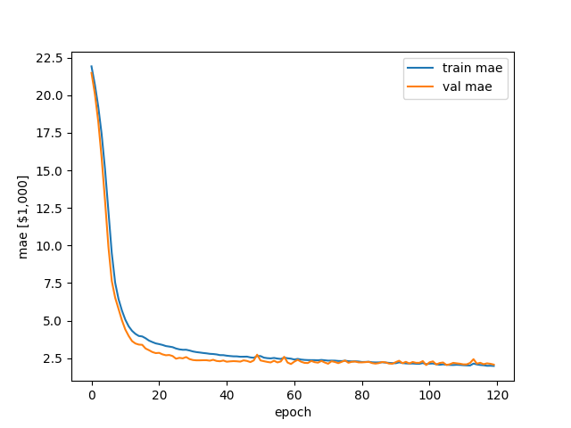

훈련 결과 시각화

```python
plt.plot(history.history['mae'], label='train mae')
plt.plot(history.history['val_mae'], label='val mae')
plt.xlabel('epoch')
plt.ylabel('mae [$1,000]')
plt.legend(loc='best')
```

### 모델 예측

```python
test_predictions = model.predict(test_data).flatten()
```

### 비교 시각화

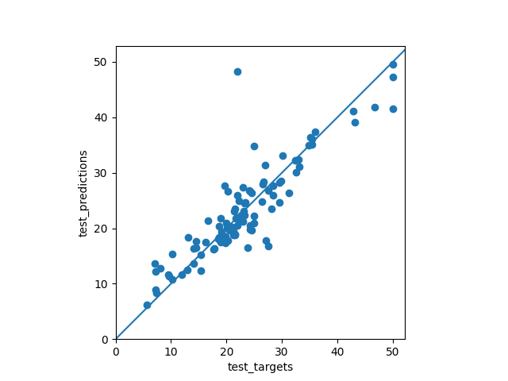

비교 시각화

```python
plt.scatter(test_targets, test_predictions)
plt.xlabel('test_targets')
plt.ylabel('test_predictions')
plt.axis('equal')
plt.axis('square')
plt.xlim([0,plt.xlim()[1]])
plt.ylim([0,plt.ylim()[1]])
_ = plt.plot([-100, 100], [-100, 100])
```

### 모델 평가

```python
test_loss, test_mae = model.evaluate(test_data, test_targets)
```

# R - keras패키지 다중 회귀 함수

### 표준화

```r
spec <- feature_spec(train_df, label ~ . ) %>%
  step_numeric_column(all_numeric(), normalizer_fn = scaler_standard()) %>%
  fit()

spec
```

```
## -- Feature Spec ----------------------------------------------------------------
## A feature_spec with 13 steps.
## Fitted: TRUE
## -- Steps -----------------------------------------------------------------------
## The feature_spec has 1 dense features.
## StepNumericColumn: CRIM, ZN, INDUS, CHAS, NOX, RM, AGE, DIS, RAD, TAX, PTRATIO, B, LSTAT
## -- Dense features --------------------------------------------------------------
```

표준화 진행

### 모델생성

```r
input <- layer_input_from_dataset(train_df %>% select(-label))

output <- input %>%
  layer_dense_features(dense_features(spec)) %>%
  layer_dense(units = 64, activation = "relu") %>%
  layer_dense(units = 64, activation = "relu") %>%
  layer_dense(units = 1)

model <- keras_model(input, output)
summary(model)
```

```
## Model: "model"
## ________________________________________________________________________________
##  Layer (type)             Output Shape      Param #  Connected to
## ================================================================================
##  AGE (InputLayer)         [(None,)]         0        []
##
##  B (InputLayer)           [(None,)]         0        []
##
##  CHAS (InputLayer)        [(None,)]         0        []
##
##  CRIM (InputLayer)        [(None,)]         0        []
##
##  DIS (InputLayer)         [(None,)]         0        []
##
##  INDUS (InputLayer)       [(None,)]         0        []
##
##  LSTAT (InputLayer)       [(None,)]         0        []
##
##  NOX (InputLayer)         [(None,)]         0        []
##
##  PTRATIO (InputLayer)     [(None,)]         0        []
##
##  RAD (InputLayer)         [(None,)]         0        []
##
##  RM (InputLayer)          [(None,)]         0        []
##
##  TAX (InputLayer)         [(None,)]         0        []
##
##  ZN (InputLayer)          [(None,)]         0        []
##
##  dense_features (DenseFea  (None, 13)       0        ['AGE[0][0]',
##  tures)                                               'B[0][0]',
##                                                       'CHAS[0][0]',
##                                                       'CRIM[0][0]',
##                                                       'DIS[0][0]',
##                                                       'INDUS[0][0]',
##                                                       'LSTAT[0][0]',
##                                                       'NOX[0][0]',
##                                                       'PTRATIO[0][0]',
##                                                       'RAD[0][0]',
##                                                       'RM[0][0]',
##                                                       'TAX[0][0]',
##                                                       'ZN[0][0]']
##
##  dense_5 (Dense)          (None, 64)        896      ['dense_features[0][0]']
##
##  dense_4 (Dense)          (None, 64)        4160     ['dense_5[0][0]']
##
##  dense_3 (Dense)          (None, 1)         65       ['dense_4[0][0]']
##
## ================================================================================
## Total params: 5,121
## Trainable params: 5,121
## Non-trainable params: 0
## ________________________________________________________________________________
```

모델 생성했다

### 컴파일링

```r
model <-  model %>%
  compile(
    loss = "mse",
    optimizer = optimizer_adam(learning_rate = 0.001),
    metrics = list("mean_absolute_error")
  )
```

컴파일링했다.

### 모델 훈련

```r
early_stop <- callback_early_stopping(monitor = "val_loss", patience = 20)

history <- model %>% fit(
  x = train_df %>% select(-label),
  y = train_df$label,
  epochs = 500,
  validation_split = 0.2,
  verbose = 0,
  callbacks = list(early_stop)
)
```

훈련했다

### 시각화

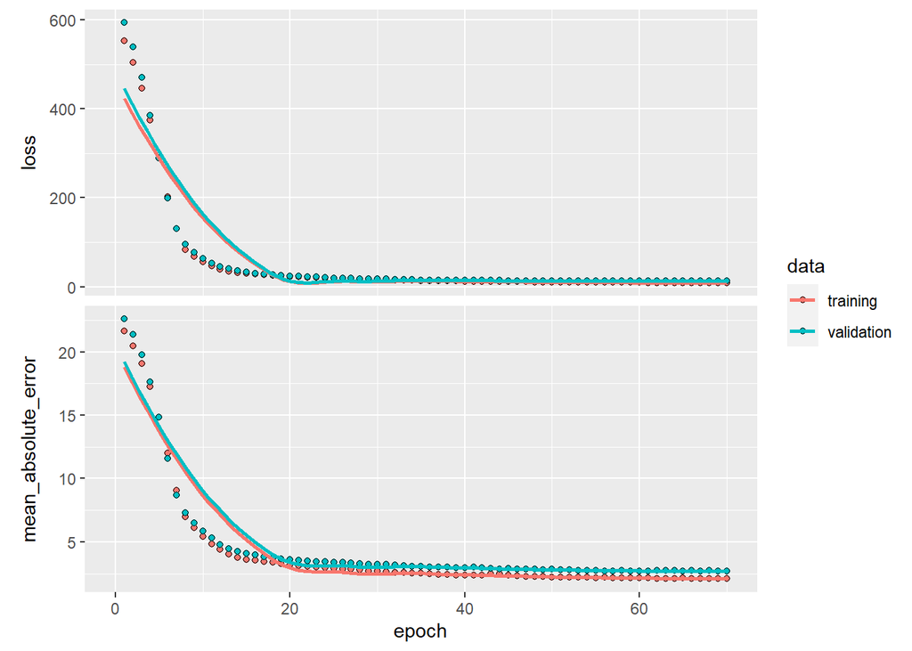

```r
plot(history) +
   scale_x_continuous(limits = c(0, 70))
```

시각화 했다.

### 예측

```r
test_predictions <- model %>% predict(test_df %>% select(-label))
test_predictions[ , 1]
```

```
##   [1]  8.369050 16.914352 20.151108 33.140045 25.574890 19.235064 26.450165
##   [8] 21.677059 19.738056 22.713867 19.986088 15.846121 15.848343 42.299942
##  [15] 19.382042 18.742964 26.395473 21.879585 19.588184 34.854248 11.687383
##  [22] 14.998857 19.539066 15.209227 20.044460 25.247225 32.429386 25.941364
##  [29] 11.103805 21.486652 19.156454 15.462103 33.111183 24.857548 17.220535
##  [36]  8.291799 14.584803 18.210072 19.249605 25.166327 28.570885 29.594027
##  [43] 15.369750 41.281471 31.690025 23.683403 26.817944 15.501552 24.792061
##  [50] 21.472660 32.570976 18.633183 12.429720 15.985317 34.460777 28.382111
##  [57] 13.326169 47.286415 34.506886 24.060091 25.757364 18.541227 15.216070
##  [64] 17.667641 23.219851 21.606216 13.674908 21.658825 15.198465  7.622138
##  [71] 34.786720 27.526012 26.013927 15.634727 25.102802 18.137680 20.510334
##  [78] 22.816011 35.755272 11.187738 19.503531 38.195892 15.326543 14.448862
##  [85] 16.928772 17.436813 21.880682 21.193420 22.369947 31.754457 18.894753
##  [92] 20.238930 24.566807 38.332516 36.378613 18.576992 36.252178 50.517345
##  [99] 26.189112 46.102379 34.282028 20.463203
```

예측했다

### 예측값 실제값 비교

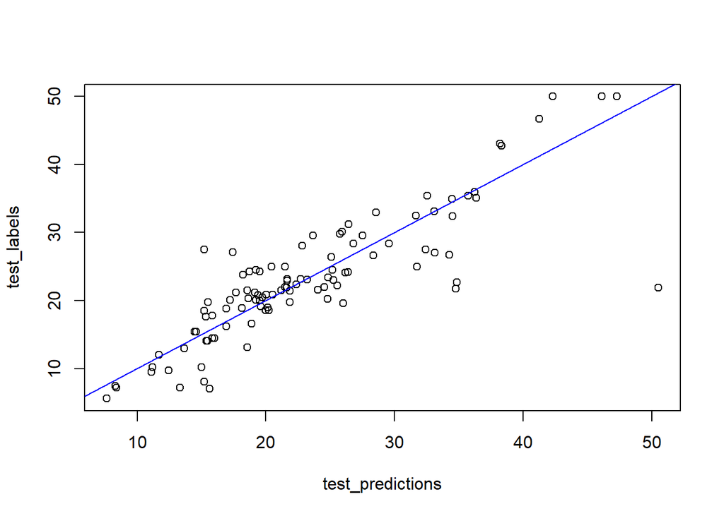

```r
plot(test_predictions, test_labels)
abline(a=0,b=1,col="blue",lty=1)
```

그래프 보니 괜찮은듯 하다.

### 모델 평가

```r
c(loss, mae) %<-% (model %>% evaluate(test_df %>% select(-label), test_df$label, verbose = 0))
paste0("Mean absolute error on test set: $", sprintf("%.2f", mae * 1000))
```

```
## [1] "Mean absolute error on test set: $3225.18"
```

# R - 내장 다중 회귀 함수

### 표준화

모두 같은 기준으로 데이터를 분석하고 해석하기 위하여 데이터의 범위가 같아지도록 표준화를 진행한다.

`scale`함수를 이용하여 표준화를 하는데, `scale`함수는 *X-Mean(x)/Sd(x)*의 식을 사용하여 표준화 한다.

표준화를 하기 전, 범주형 컬럼과 예측하려는 컬럼을 제거하고 표준화를 진행한다.

```r
train_scale <- train_df[, c(-4,-14)] %>% scale() %>% cbind(label) %>% data.frame()
head(train_scale)
```

```
##          CRIM         ZN      INDUS        NOX         RM        AGE        DIS
## 1 -0.27190919 -0.4830166 -0.4352220 -0.1650220 -0.1762241  0.8120550  0.1165538
## 2 -0.40292691  2.9880792 -1.3322597 -1.2136770  1.8920002 -1.9079948  1.2460402
## 3  0.12478548 -0.4830166  1.0270523  0.6278635 -1.8274222  1.1091131 -1.1859686
## 4 -0.40099633 -0.4830166 -0.8683253 -0.3611120 -0.3241557 -1.2351404  1.1058088
## 5 -0.00562732 -0.4830166  1.0270523  1.3269669  0.1534520  0.6939476 -0.5778555
## 6 -0.37455796 -0.4830166 -0.5468011 -0.5486763 -0.7876746  0.1893067  0.4831160
##          RAD        TAX    PTRATIO         B      LSTAT label
## 1 -0.6254735 -0.5944330  1.1470781 0.4475222  0.8241983  15.2
## 2 -0.8554019 -0.3480010 -1.7160613 0.4313711 -1.3275563  42.3
## 3  1.6738104  1.5633491  0.7835049 0.2203441 -1.3068796  50.0
## 4 -0.5105093 -1.0933074  0.7835049 0.4475222 -0.6521177  21.1
## 5  1.6738104  1.5633491  0.7835049 0.3893995  0.2631706  17.7
## 6 -0.5105093 -0.7146437  0.5108249 0.3862118 -0.1379572  18.5
```

```r
test_scale <- test_df[, c(-4,-14)] %>% scale() %>%  cbind(label2) %>%  data.frame()
head(test_scale)
```

```
##         CRIM         ZN      INDUS         NOX         RM        AGE        DIS
## 1  2.7902510 -0.5053538  0.9648441  1.22569297  0.1187549  1.1417595 -0.9148350
## 2 -0.5525772 -0.5053538 -0.1771423  0.02585218 -0.6561560  0.8972270 -0.6968914
## 3 -0.5652924 -0.5053538 -0.8575346 -0.26501831 -0.5490665 -0.7387300  0.3362298
## 4 -0.3385159 -0.5053538  1.1737612  0.55305496 -0.1549180  0.8868947 -0.9300873
## 5 -0.5622141 -0.5053538 -0.9563468 -0.86493870 -0.3467865 -0.3461003 -0.1110863
## 6 -0.5234915 -0.5053538 -0.2223135  0.37126090 -0.6368204 -0.8351653 -0.6850005
##          RAD         TAX     PTRATIO          B      LSTAT label2
## 1  1.5982005  1.40086438  0.90068257 -4.2572715  2.5008975    7.2
## 2 -0.4537548  0.08174058 -0.28345864  0.3890235  0.5831630   18.8
## 3 -0.5677523 -1.09081391  0.90068257  0.4136639 -0.3831720   19.0
## 4 -0.5677523 -0.08174058 -1.81297437 -0.3189774 -1.0164426   27.0
## 5 -0.7957474 -0.96115645  0.06191588  0.3915507 -0.5773352   22.2
## 6 -0.4537548 -0.14938795  0.40729040  0.4136639  0.1918496   24.5
```

### 다중회귀모델 작성

표준화한 데이터로 다중회귀모델을 작성한다.

```r
model <- lm(label ~ ., data = train_scale)
summary(model)
```

```
##
## Call:
## lm(formula = label ~ ., data = train_scale)
##
## Residuals:
##      Min       1Q   Median       3Q      Max
## -10.8947  -2.8768  -0.6159   1.8684  25.3458
##
## Coefficients:
##             Estimate Std. Error t value Pr(>|t|)
## (Intercept)  22.3950     0.2422  92.460  < 2e-16 ***
## CRIM         -1.1626     0.3172  -3.665 0.000282 ***
## ZN            1.3697     0.3657   3.745 0.000208 ***
## INDUS         0.1838     0.4754   0.387 0.699298
## NOX          -2.3407     0.5191  -4.510 8.60e-06 ***
## RM            2.4048     0.3377   7.121 5.19e-12 ***
## AGE           0.2994     0.4360   0.687 0.492698
## DIS          -3.4843     0.4916  -7.087 6.43e-12 ***
## RAD           3.2033     0.6930   4.622 5.17e-06 ***
## TAX          -2.3440     0.7501  -3.125 0.001910 **
## PTRATIO      -2.1229     0.3240  -6.552 1.79e-10 ***
## B             0.8652     0.2878   3.007 0.002813 **
## LSTAT        -4.0696     0.4041 -10.072  < 2e-16 ***
## ---
## Signif. codes:  0 '***' 0.001 '**' 0.01 '*' 0.05 '.' 0.1 ' ' 1
##
## Residual standard error: 4.868 on 391 degrees of freedom
## Multiple R-squared:  0.7289, Adjusted R-squared:  0.7206
## F-statistic: 87.62 on 12 and 391 DF,  p-value: < 2.2e-16
```

다중회귀실시 결과는 INDUS계수와 AGE계수는 유의하지 않은 것으로 나타나고 있다.

변수선택법을 통하여 다시 다중회귀분석을 시행한다.

```r
model2 <- step(model)
```

```
## Start:  AIC=1291.67
## label ~ CRIM + ZN + INDUS + NOX + RM + AGE + DIS + RAD + TAX +
##     PTRATIO + B + LSTAT
##
##           Df Sum of Sq     RSS    AIC
## - INDUS    1      3.54  9270.9 1289.8
## - AGE      1     11.18  9278.6 1290.2
## <none>                  9267.4 1291.7
## - B        1    214.24  9481.6 1298.9
## - TAX      1    231.48  9498.9 1299.6
## - CRIM     1    318.31  9585.7 1303.3
## - ZN       1    332.39  9599.8 1303.9
## - NOX      1    482.00  9749.4 1310.2
## - RAD      1    506.38  9773.8 1311.2
## - PTRATIO  1   1017.56 10284.9 1331.8
## - DIS      1   1190.45 10457.8 1338.5
## - RM       1   1201.75 10469.1 1338.9
## - LSTAT    1   2404.22 11671.6 1382.8
##
## Step:  AIC=1289.82
## label ~ CRIM + ZN + NOX + RM + AGE + DIS + RAD + TAX + PTRATIO +
##     B + LSTAT
##
##           Df Sum of Sq     RSS    AIC
## - AGE      1     11.13  9282.1 1288.3
## <none>                  9270.9 1289.8
## - B        1    212.69  9483.6 1297.0
## - TAX      1    242.98  9513.9 1298.3
## - CRIM     1    321.45  9592.4 1301.6
## - ZN       1    329.01  9599.9 1301.9
## - NOX      1    496.91  9767.8 1308.9
## - RAD      1    515.15  9786.1 1309.7
## - PTRATIO  1   1020.98 10291.9 1330.0
## - RM       1   1199.93 10470.9 1337.0
## - DIS      1   1299.21 10570.1 1340.8
## - LSTAT    1   2404.47 11675.4 1381.0
##
## Step:  AIC=1288.31
## label ~ CRIM + ZN + NOX + RM + DIS + RAD + TAX + PTRATIO + B +
##     LSTAT
##
##           Df Sum of Sq     RSS    AIC
## <none>                  9282.1 1288.3
## - B        1    221.04  9503.1 1295.8
## - TAX      1    236.94  9519.0 1296.5
## - ZN       1    318.66  9600.7 1299.9
## - CRIM     1    320.45  9602.5 1300.0
## - NOX      1    492.06  9774.1 1307.2
## - RAD      1    504.77  9786.8 1307.7
## - PTRATIO  1   1009.89 10291.9 1328.0
## - RM       1   1333.93 10616.0 1340.6
## - DIS      1   1561.15 10843.2 1349.1
## - LSTAT    1   2574.44 11856.5 1385.2
```

```r
summary(model2)
```

```
##
## Call:
## lm(formula = label ~ CRIM + ZN + NOX + RM + DIS + RAD + TAX +
##     PTRATIO + B + LSTAT, data = train_scale)
##
## Residuals:
##      Min       1Q   Median       3Q      Max
## -10.8532  -2.8512  -0.6401   1.9486  25.4177
##
## Coefficients:
##             Estimate Std. Error t value Pr(>|t|)
## (Intercept)  22.3950     0.2418  92.623  < 2e-16 ***
## CRIM         -1.1655     0.3164  -3.683 0.000262 ***
## ZN            1.3242     0.3605   3.673 0.000273 ***
## NOX          -2.1974     0.4814  -4.564 6.71e-06 ***
## RM            2.4483     0.3258   7.515 3.88e-13 ***
## DIS          -3.6412     0.4479  -8.130 5.66e-15 ***
## RAD           3.0900     0.6684   4.623 5.14e-06 ***
## TAX          -2.2059     0.6965  -3.167 0.001658 **
## PTRATIO      -2.0809     0.3182  -6.539 1.93e-10 ***
## B             0.8760     0.2863   3.059 0.002371 **
## LSTAT        -3.9671     0.3800 -10.440  < 2e-16 ***
## ---
## Signif. codes:  0 '***' 0.001 '**' 0.01 '*' 0.05 '.' 0.1 ' ' 1
##
## Residual standard error: 4.86 on 393 degrees of freedom
## Multiple R-squared:  0.7285, Adjusted R-squared:  0.7216
## F-statistic: 105.4 on 10 and 393 DF,  p-value: < 2.2e-16
```

이번 회귀 결과는 모든 회귀계수가 유의하다고 판단되어진다.

따라서, 회귀 결과를 이용하여 분석을 시행하고자 한다.

### 독립성 검정

```r
dwtest(model2)
```

```
##
##  Durbin-Watson test
##
## data:  model2
## DW = 2.0802, p-value = 0.7874
## alternative hypothesis: true autocorrelation is greater than 0
```

더빈 왓슨 값의 p-value가 0.05이상이므로 독립성 있다고 판단한다.

DW의 값이 1~3 이내이면 잔차에 유의미한 자기 상관이 없다고 판단한다.

### 등분산성 검정

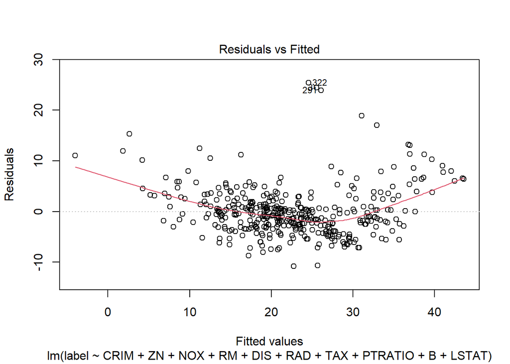

잔차 0을 기준으로 적합값의 분포가 좌우 균등하면

잔차들은 등분산성과 차이가 없다고 볼수 있다.

### 정규성 검정, 다중 공선성 확인

```r
model2_residual <- residuals(model2) # 잔차
shapiro.test(model2_residual)
```

```
##
##  Shapiro-Wilk normality test
##
## data:  model2_residual
## W = 0.89692, p-value = 6.996e-16
```

shapiro의 p-value값은 0.05이하이므로 정규분포를 따르지 않는다고 판단한다.

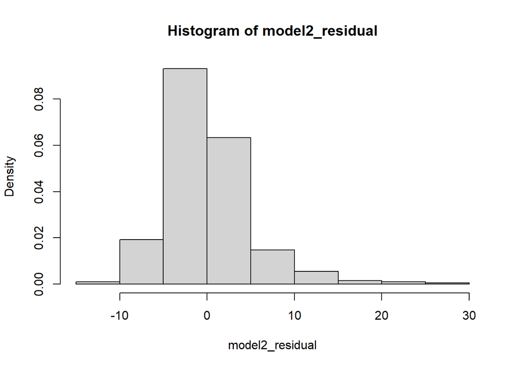

```r
hist(model2_residual, freq = F)
```

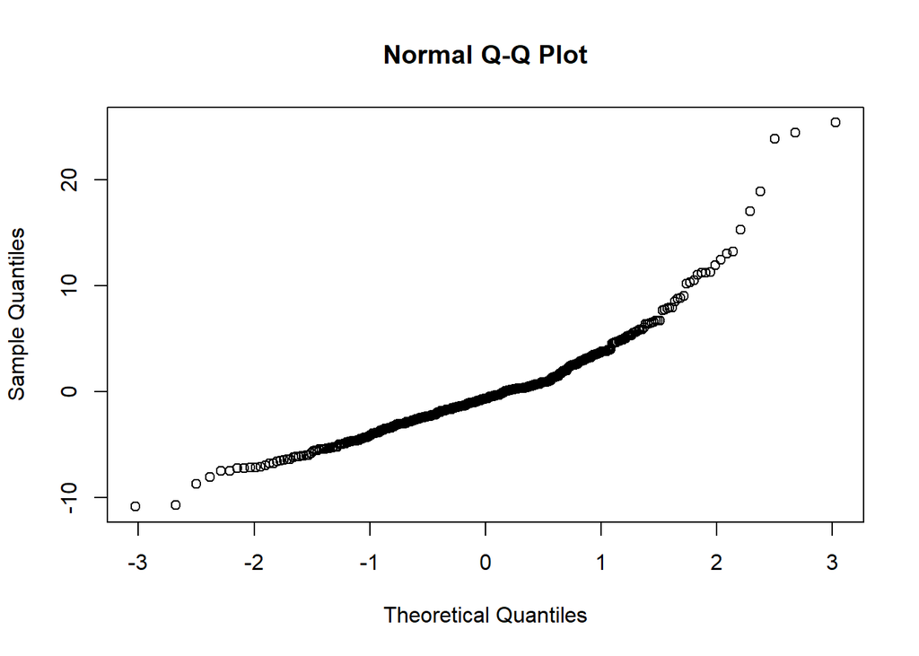

```r
qqnorm(model2_residual)
```

```r
vif(model2) > 10
```

```
##    CRIM      ZN     NOX      RM     DIS     RAD     TAX PTRATIO       B   LSTAT
##   FALSE   FALSE   FALSE   FALSE   FALSE   FALSE   FALSE   FALSE   FALSE   FALSE
```

다중 공선성 문제도 없다고 판단한다.

### 예측

```r
model2_pred <- predict(model2, newdata = test_scale)
```

### 예측과 실측값 비교

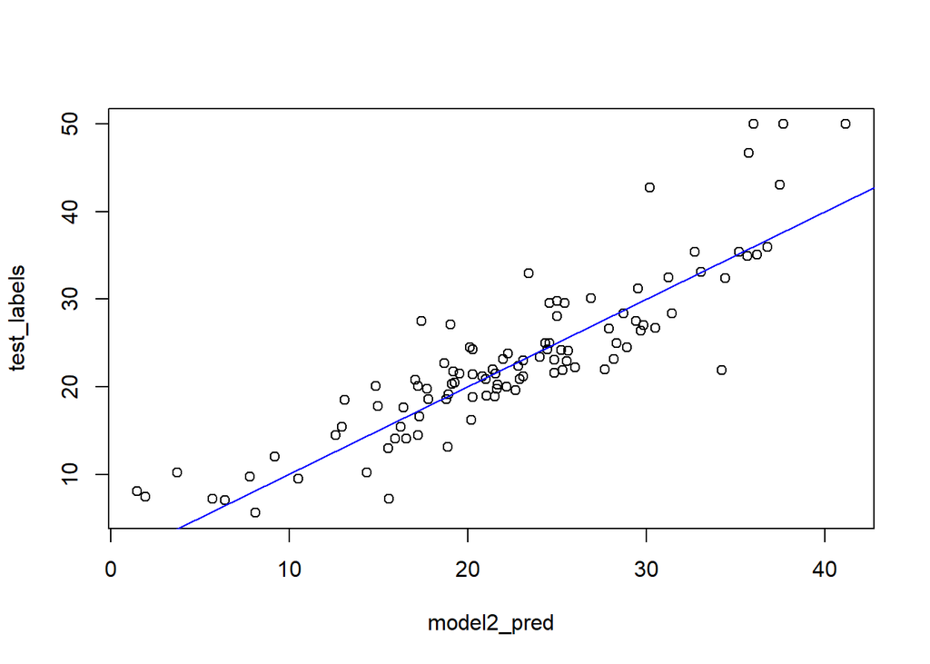

```r
plot(model2_pred, test_labels)
abline(a=0,b=1,col="blue",lty=1)
```

### 모델 평가

```r
mean(abs(model2_pred - test_labels))
```

```
## [1] 3.17729
```

# 결론

# 참조

네이버